# Analysis of sheep astrocytes in response to inflammation and cholinergic manipulation

# Contents

**Author**: James W. MacDonald  
**Compiled**: Fri Mar 22 10:40:22 2019

# 1 Introduction

*Please note that this is a re-analysis of these data, where we exclude animal 4786 from the microglia samples, and use conventional linear models rather than generalized linear models, in order to fit array weights to the microglia samples to down-weight the one sample with exceedingly low counts. We keep the generalized linear model for the astrocyte analysis.*

This is an analysis of fetal sheep astrocytes that were controls or exposed to LPS, LPS plus an agonist or LPS plus an antagonist. One of the sheep was exposed to LPS *in vivo* as well as *in vitro*. We characterize this animal as a ‘double hit’ and the others as ‘single hit’. The table below describes the set of samples for this experiment.

Samples used in this analysis. Treat.Number in this table lists the number of treatments the animal received (the single or double hit animals).

| Sample | Treatment | Gender | Treat.Number |
| --- | --- | --- | --- |
| 4414T1 | Ctrl | F | 1 |
| 4414T1 | LPS100 | F | 1 |
| 4414T1 | LPS100+B100 | F | 1 |
| 4414T1 | LPS100+A10 | F | 1 |
| 4414T2 | Ctrl | F | 1 |
| 4414T2 | LPS100 | F | 1 |
| 4414T2 | LPS100+B100 | F | 1 |
| 4414T2 | LPS100+A10 | F | 1 |
| 4502P | Ctrl | M | 1 |
| 4502P | LPS100 | M | 1 |
| 4502P | LPS100+B100 | M | 1 |
| 4502P | LPS100+A10 | M | 1 |
| 711P | LPS100 | M | 2 |
| 711P | LPS100+B100 | M | 2 |
| 711P | LPS100+A10 | M | 2 |

The goal for this analysis is to compare the single hit LPS treated samples to Control, as well as making comparisons between the LPS treated samples (e.g., testing for changes due to the additional agonist or antagonist treatment). The double hit samples have no replicates, so we can only make the directed comparisons between the single and double hit samples. For example, comparing the single and double hit LPS treated samples.

We aligned the reads to the Oar_v3.1 transcriptome using the salmon aligner (Patro, Duggal, and Kingsford 2015), which infers the most likely transcript for each read using a quasi-mapping algorithm. We then ‘collapse’ the transcript read counts to the gene level by summing up the reads for each gene’s transcripts, using the Bioconductor tximport package (Soneson, Love, and Robinson 2015). In the end we have a set of read counts per gene, for each sample.

We also want to make some comparisons to some existing data that were generated using fetal sheep microglia. The microglia samples we used are presented in the next table.

Microglia samples used in this analysis.

| File | Animal | Treatment |
| --- | --- | --- |
| Mingju_1 | 5458T | Ctrl |
| Mingju_2 | 5458T | LPS100 |
| Mingju_3 | 5458T | LPS100+B100 |
| Mingju_4 | 5458T | LPS100+A10 |
| Mingju_5 | 3872T-R2 | Ctrl |
| Mingju_6 | 3872T-R2 | LPS100 |
| Mingju_7 | 3872T-R2 | LPS100+B100 |
| Mingju_8 | 3872T-R2 | LPS100+A10 |
| Mingju_9 | 4414T-R2 | Ctrl |
| Mingju_10 | 4414T-R2 | LPS100 |
| Mingju_11 | 4414T-R2 | LPS100+B100 |
| Mingju_12 | 4414T-R2 | LPS100+A10 |

# 2 Exploratory data analysis

We first present a table of read depth for each sample.

|  | Total reads | Mapped reads |
| --- | --- | --- |
| 4414T1_Ctrl | 32.20 | 19.73 |
| 4414T1_LPS100 | 30.66 | 19.32 |
| 4414T1_LPS+B100 | 25.17 | 17.10 |
| 4414T1_LPS+A10 | 27.55 | 15.46 |
| 4414T2_Ctrl | 29.08 | 18.17 |
| 4414T2_LPS100 | 27.90 | 16.73 |
| 4414T2_LPS+B100 | 31.16 | 16.89 |
| 4414T2_LPS+A10 | 27.27 | 18.89 |
| 4502P_Ctrl | 39.23 | 25.80 |
| 4502P_LPS100 | 37.65 | 24.38 |
| 4502P_LPS+B100 | 33.55 | 24.05 |
| 4502P_LPS+A10 | 37.26 | 21.80 |
| 711P_LPS100 | 32.87 | 21.49 |
| 711P_LPS+B100 | 31.34 | 19.84 |
| 711P_LPS+A10 | 34.76 | 20.37 |

We also present the read depth for the microglia samples.

Read counts for the microglia samples. Please note that some of these samples have low total reads, and even lower numbers of mapped reads.

|  | Total reads | Mapped reads |
| --- | --- | --- |
| 5458T_Ctrl | 32.75 | 15.09 |
| 5458T_LPS100 | 32.93 | 13.23 |
| 5458T_LPS100+B100 | 32.99 | 16.89 |
| 5458T_LPS100+A10 | 31.59 | 15.34 |
| 3872T-R2_Ctrl | 31.76 | 16.46 |
| 3872T-R2_LPS100 | 41.53 | 23.90 |
| 3872T-R2_LPS100+B100 | 31.68 | 15.72 |
| 3872T-R2_LPS100+A10 | 36.86 | 19.83 |
| 4414T-R2_Ctrl | 33.58 | 18.26 |
| 4414T-R2_LPS100 | 25.89 | 3.24 |
| 4414T-R2_LPS100+B100 | 36.09 | 16.23 |
| 4414T-R2_LPS100+A10 | 33.17 | 13.18 |

From an alignment standpoint, we have good data. We get a reasonable proportion of reads that align, and the QC on the FASTQ files looks good as well (results not shown).

One of the best ways to assess quality is a 3D PCA plot. PCA, or principal components analysis, is a method to take high dimensional data and reduce to only a few dimensions in order to visualize how similar samples of the same type are. The first dimension captures the largest amount of variability between samples, the second dimension captures the next largest amount of variability, and so on. The above link will load an HTML page with an interactive plot that you can adjust by clicking on the plot and moving your mouse. This interactive plot is nice for looking at the data from various angles, but is not good for publications. For that purpose we can make some static 3D plots.

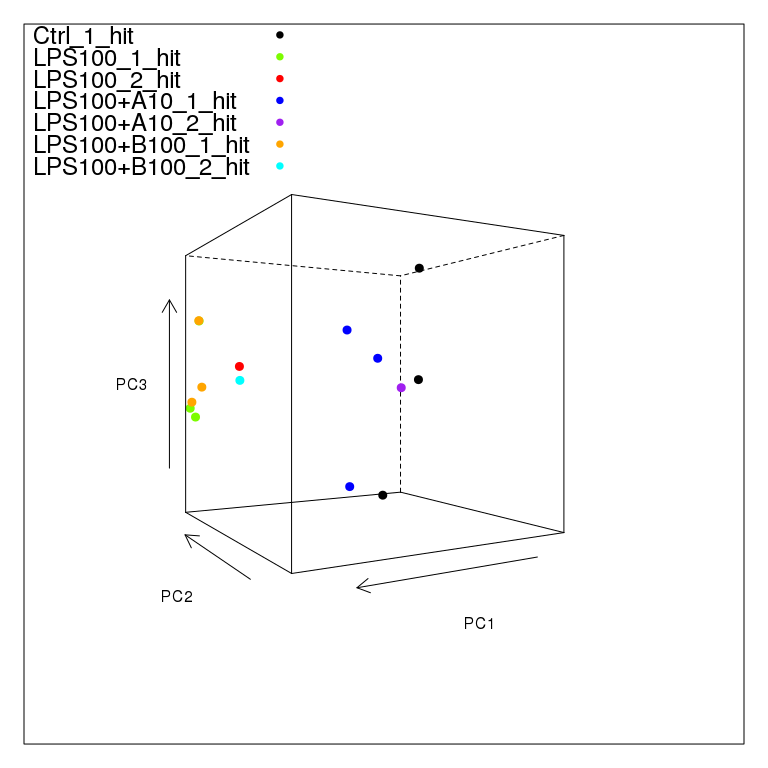

Static 3D plot of these samples. The angle of the plot was chosen to give the best viewpoint to show differences between the sample types. We also output a high-resolution TIFF version of this plot, which can be found here. Note here that there are three of the LPS_100_1_hit samples in the plot - it just so happens that the third sample is obscured by the uppermost LPS+B100_1_hit sample.

The above plot includes both the single and double hit samples, and it might be of interest to have just the single hit samples on their own plot, which we generate below.

[figure not shown]

Static 3D plot of the single-hit samples. The angle of the plot was chosen to give the best viewpoint to show differences between the sample types. We also output a high-resolution TIFF version of this plot, which can be found here.

These plots indicate that there are large differences between the different treatment groups, and much smaller differences within each group, indicating that we are getting good signal and will likely have lots of differentially expressed genes.

# 3 Model fit and results

To make these comparisons we use the Bioconductor limma package (Smyth 2004), which includes a function that is intended to convert the count data to log counts/million, as well as estimating observation-level weights (e.g. a weight for each gene, for each sample). We can then fit a conventional weighted linear model to these data, as the weights account for any dependence between the mean and variance. For the microglia samples we also compute sample-specific weights that are intended to down-weight any samples that are not very similar to other samples of the same type. This is an alternative to simply excluding the sample.

We fit the model described above, including a blocking effect for each animal, and made the requested comparisons, incorporating a fold change criterion into the test. In other words, the conventional test for a difference is between the null hypothesis $H_0: \beta = 0$ versus the alternative hypothesis $H_A: \beta \neq 0$, but this may include very small changes that are likely to be biologically meaningless. One alternative to exclude such genes is to use a *post hoc* fold change adjustment, where we select genes based on the observed fold change between groups. This is problematic because we ignore the imprecision in our estimate of fold change. A better method is to incorporate the fold change into our inference, where we test $H_0: \beta < |c|$ against the alternative $H_A: \beta \geq |c|$, for some constant fold change. By doing this, we are testing to see if we have evidence that the underlying population differences are larger than a given fold change, rather than simply testing that our sample data fulfill those criteria. We used a 1.5-fold change, and a false discovery rate (FDR) of 0.05 as criteria to define significantly differentially expressed genes.

We present the number of genes for each comparison, as well as links to results in the table below.

Number of significant genes in astroglia samples at an FDR < 0.05 and a 1.5-fold change.

| Comparison | Number significant |
| --- | --- |
| LPS100_1_hit vs Ctrl_1_hit | 1835 |
| LPS100+A10_1_hit vs Ctrl_1_hit | 1725 |
| LPS100+B100_1_hit vs Ctrl_1_hit | 1744 |
| LPS100+A10_1_hit vs LPS100_1_hit | 273 |
| LPS100+B100_1_hit vs LPS100_1_hit | 0 |
| LPS100+A10_1_hit vs LPS100+B100_1_hit | 292 |
| LPS100_1_hit vs LPS100_2_hit | 3761 |
| LPS100+A10_1_hit vs LPS100+A10_2_hit | 3307 |
| LPS100+B100_1_hit vs LPS100+B100_2_hit | 3860 |

Number of significant genes in microglia samples at an FDR < 0.05 and a 1.5-fold change.

| Comparison | Number significant |
| --- | --- |
| LPS100 vs Ctrl | 1779 |
| LPS100+A10 vs Ctrl | 4721 |
| LPS100+B100 vs Ctrl | 4049 |
| LPS100+A10 vs LPS100 | 8 |
| LPS100+B100 vs LPS100 | 0 |
| LPS100+A10 vs LPS100+B100 | 1132 |

The links in the above table will load HTML tables containing the genes that were significantly different in this analysis. By default the table shows only 10 rows, and is sorted on the first column. You can change the number of rows using the drop-down at the top left of the page, and can sort on any column by simply clicking on the header of the column you want to sort by. Each row has a small plot showing the relative differences between the two groups, but in order to fit the plot into the table we have to strip off the axis labels. If you right-click on any plot and choose ‘Open in new tab’, you will be presented with a full size plot that does have axis labels.

The first four columns in the table contain annotation information, including links to Ensembl and NCBI, and the gene symbol and description (if available). We get the symbol and description from Ensembl’s Biomart server, and for some reason not all of the symbols and/or descriptions are available from that database. The logFC column shows the log fold change between the groups being compared. The sign of the fold change indicates if the gene is up or down-regulated, and the title of the table indicates the direction of comparison. For example, LPS100_1_hit vs Ctrl_1_hit indicates that we are comparing the LPS treated - Control for the single hit samples, so a positive fold change means the gene is up-regulated in LPS treated samples, and a negative fold change indicates it is down-regulated in LPS treated samples. You can convert the log fold changes to linear scale by exponentiating; if the logFC is 1.23, then the linear fold change is $2^{1.23}$ = 2.35.

The logCPM column can be interpreted as a measure of the relative expression for a given gene. All things equal, a larger value indicates a higher level of gene expression. The FDR is a is a measure that estimates the maximum proportion of false discoveries in a given set of genes. We selected genes at an FDR < 0.05, meaning that we expect at most that 5% of the genes selected are false positives.

We also output the same set of tables in Excel format - you can find them in the spreadsheets subdirectory that accompanies this document. In addition, we output all (post filtered) genes in two Excel spreadsheets that is primarily intended for analysis using IPA (Ingenuity Pathway Analysis), called Frasch_pid1708_astroglia_ingenuity.xlsx and Frasch_pid1708_microglia_ingenuity.xlsx. These files can be useful to look at results for a given gene, across all comparisons, or to simply look for genes that might not appear in the sets of differentially expressed genes.

## 3.1 Venn diagrams

Please note that the genes in any intersection between comparisons have to be significantly differentially expressed in both (or all three, depending on the intersection) of the comparisons. In addition, the direction of change has to be the same as well. For example, if a given gene is differentially expressed in LPS vs control and LPS+A10 vs control, *and it is either up or down-regulated in both comparisons as well*, then it will be listed in the intersection between those two comparisons. If it is significant in both comparisons, but is up-regulated in one comparison, but down-regulated in the other, then it will be listed in the unique portion of the Venn diagram for each comparison.

## 3.2 Comparison to microglia samples

*Please note that differences between the astrocyte and microglia samples are confounded by technical differences. In other words, we cannot say if any differences between the two cell types represent real biological differences or are simply technical differences due to running samples at different times, or some unknown combination of the two.*

First, we can take a look at a PCA plot that includes just the single-hit LPS and control samples for microglia and astrocytes (we exclude the two-hit samples because there is no two-hit control for astrocytes).

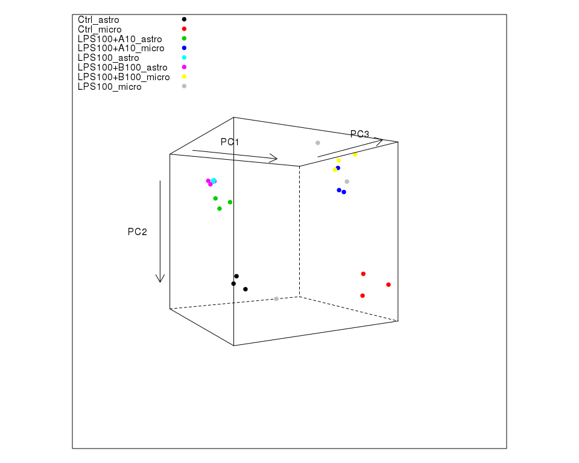

PCA plot of the microglia and astrocyte samples. Here we can see that the astrocytes and microglia separate on the first principal component, and the second principal component captures the LPS treatement differences. The third principal component captures some intra-treatment variability for the microglia samples, particularly for one of the LPS treated microglia samples.

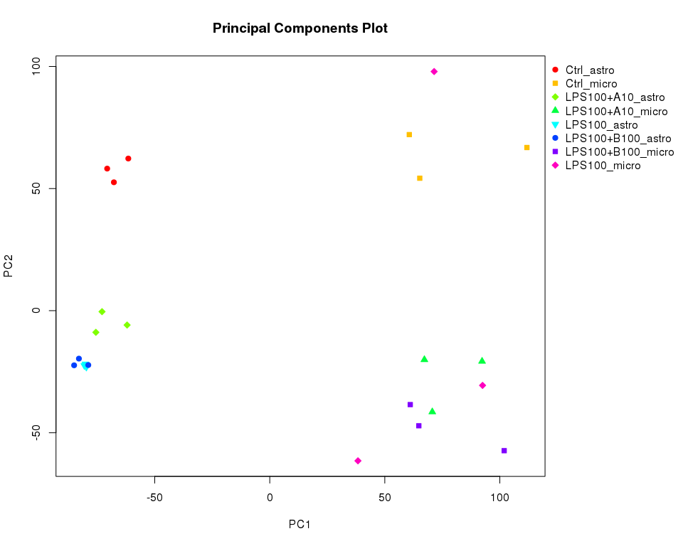

PCA plot of the microglia and astrocyte samples, showing just the first two principal components. It is clear from this plot that the largest differences are between the cell types. But as noted above, there may not actually be large differences between the two cell types, and this may simply represent technical differences due to the fact that these experiments were run at different times, using different reagents, possibly by different people.

A high resolution tiff of the 2D plot can be found here.

We can do a few different things to compare the astrocyte and microglia results. Given the confounding between the two experiments, it is not advisable to make any direct comparisons between microglia and astrocyte samples. But we can still make comparisons.

Alternatives to Venn diagrams would be some sort of gene set testing, where we try to detect pathways that are affected in both cell types. This sort of analysis is far more complex, and if you want to do something like that we should have a meeting to discuss the parameters first.

# 4 References

Patro, Rob, Geet Duggal, and Carl Kingsford. 2015. “Salmon: Accurate, Versatile and Ultrafast Quantification from Rna-Seq Data Using Lightweight-Alignment.” *BioRxiv*. Cold Spring Harbor Labs Journals, 021592.

Smyth, G.K. 2004. “Linear Models and Empirical Bayes Methods for Assessing Differential Expression in Microarray Experiments.” *Statistical Applications in Genetics and Molecular Biology* 3: Article 3.

Soneson, Charlotte, Michael I. Love, and Mark D. Robinson. 2015. “Differential Analyses for RNA-Seq: Transcript-Level Estimates Improve Gene-Level Inferences.” *F1000Research* 4 (1521). doi:10.12688/f1000research.7563.1.